# Logistic Regression Analyses

- Show All Code
- Hide All Code
- View Source

Author

Cormac Monaghan

Published

January 9, 2024

# Introduction

This document performs multiple binary logistic regression analyses to assess how well several health related problems and health protective behaviors (DVs) are explained by procrastination (IV). This analysis uses data from the 2020 wave of the [Health and Retirement Study (HRS)](https://hrs.isr.umich.edu/).

# Logistic Regression

Logistic regression is a statistical method used for predicting the probability of a binary outcome based on one or more predictor variables. Unlike linear regression, which predicts continuous values, logistic regression models the probability of the dependent variable belonging to a particular category.

The logistic regression equation can be written as:

$$P(Y = 1 ∣ X) = \frac{1}{1 + e^{{\beta_{0} + \beta_{1}X_{1} + \beta_{2}X_{2} + \dots + \beta_{n}X_{x}}}}$$
where $P(Y = 1 ∣ X)$ is the probability of the dependent variable ($Y$) being 1 given the values of predictors ($X$). $e$ is the base of the natural logarithm. $\beta_{0}, \beta_{1}, \beta_{2}, \dots \beta_{n}$ are the coefficients representing the effect of each predictor variable on the outcome and $X_{1}, X_{2}, \dots X_{n}$ are the values of the predictor variables.

## Defining health problems and health protection

Within the HRS dataset, we have a range of both health problems and health protective behaviors. These have been coded as either $0$ (not present/done) or $1$ (present/done).

```r
health_data %>%
  select(Back_pain:Alcohol, Smoker_current, Blood_pressure:Dental_visit_2_years,
         Total_procrastination) %>%
  str()
```

```
tibble [1,368 × 16] (S3: tbl_df/tbl/data.frame)
 $ Back_pain            : num [1:1368] 0 1 0 0 1 0 0 0 0 1 ...
 $ Headache             : num [1:1368] 0 0 0 0 0 0 0 0 0 0 ...
 $ Fatigue              : num [1:1368] 0 0 0 0 0 0 1 0 0 NA ...
 $ Alcohol              : num [1:1368] 1 0 0 0 0 1 0 1 1 0 ...
 $ Smoker_current       : num [1:1368] NA NA NA 0 0 NA NA NA 0 1 ...
 $ Blood_pressure       : num [1:1368] 0 0 1 1 1 1 1 1 1 1 ...
 $ Diabetes             : num [1:1368] 1 0 0 1 0 0 0 0 0 0 ...
 $ Cholesterol          : num [1:1368] 1 0 0 0 1 0 1 0 0 0 ...
 $ Heart_condition      : num [1:1368] 0 0 0 0 1 0 1 0 0 1 ...
 $ Prostate_exam        : num [1:1368] NA NA 1 NA NA NA NA 0 NA NA ...
 $ Mammogram            : num [1:1368] 1 1 NA 0 1 0 0 NA 1 0 ...
 $ Cholesterol_screening: num [1:1368] 1 1 1 1 1 1 1 1 1 1 ...
 $ Pap_smear            : num [1:1368] 0 0 NA 0 0 0 0 NA 0 1 ...
 $ Flu_shot             : num [1:1368] 1 1 1 1 1 1 1 1 0 0 ...
 $ Dental_visit_2_years : num [1:1368] 1 1 1 0 1 0 0 1 0 0 ...
 $ Total_procrastination: num [1:1368] 22 41 5 60 16 20 37 30 21 36 ...
```

For the purpose of our analysis we will define these variables into 2 vectors: one for problems and one for protective behaviors

```r
# Defining a vector of health problems
health_problems <- c("Back_pain", "Headache", "Fatigue",
                     "Alcohol", "Smoker_current", "Blood_pressure",
                     "Diabetes", "Cholesterol", "Heart_condition")

# Defining a vector of health protective behaviors
health_protection <- c("Prostate_exam", "Mammogram", "Cholesterol_screening",
                       "Pap_smear", "Flu_shot", "Dental_visit_2_years")
```

## Performing logistic analysis

For each variable we will apply a custom function from the Functions.R script. This function (`logit_model()`) applies a `glm()` model with the `family = binomial(link = "logit")` argument, whilst also storing summary output, various fit metrics generated by the [DescTools](https://andrisignorell.github.io/DescTools/) package, and the relevant odds ratio for that variable.

```r
# Fitting binary logistic regressions (with no covariate) ----------------------
# Fitting (health problems)
problem_models_base <- lapply(health_problems, logit_model,
                              predictor = "Total_procrastination",
                              data = health_data, type = "base")

# Fitting (health protection)
protection_models_base <- lapply(health_protection, logit_model,
                                 predictor = "Total_procrastination",
                                 data = health_data, type = "base")

# Fitting binary logistic regressions (with covariate) -------------------------
problem_models_control <- lapply(health_problems, logit_model,
                                 predictor = "Total_procrastination",
                                 data = health_data, type = "control")

protection_models_control <- lapply(health_protection, logit_model,
                                    predictor = "Total_procrastination",
                                    data = health_data, type = "control")
```

# Visualisation

To better summarize and visualise each model we can create individual HTML tables using the [sjPlot](https://strengejacke.github.io/sjPlot/) package and an odds ratio plot using the `log_odds_plot()` function, again from the Functions.R.

## Health Problems

### Base Model

```r
sjPlot::tab_model(
  problem_models_base[[1]]$model, problem_models_base[[2]]$model,
  problem_models_base[[3]]$model, problem_models_base[[4]]$model,
  problem_models_base[[5]]$model, problem_models_base[[6]]$model,
  problem_models_base[[7]]$model, problem_models_base[[8]]$model,
  problem_models_base[[9]]$model,
  pred.labels = c("(Intercept)", "Procrastination"),
  title = "Binary Logistic Regression Analysis Predicting Likelihood of Health Problems",
  dv.labels = health_problems,
  collapse.ci = TRUE, p.style = "stars"
)
```

Binary Logistic Regression Analysis Predicting Likelihood of Health Problems

|  | Back Pain | Headache | Fatigue | Drinking | Smoking | Blood Pressure | Diabetes | Cholesterol | Heart Condition |
| --- | --- | --- | --- | --- | --- | --- | --- | --- | --- |
| Predictors | Odds Ratios | Odds Ratios | Odds Ratios | Odds Ratios | Odds Ratios | Odds Ratios | Odds Ratios | Odds Ratios | Odds Ratios |
| (Intercept) | 0.30 *** (0.23 – 0.41) | 0.04 *** (0.03 – 0.07) | 0.05 *** (0.03 – 0.07) | 2.22 *** (1.67 – 2.97) | 0.15 *** (0.09 – 0.25) | 0.84 (0.63 – 1.12) | 0.14 *** (0.10 – 0.19) | 0.29 *** (0.21 – 0.40) | 0.24 *** (0.17 – 0.34) |
| Procrastination | 1.03 *** (1.02 – 1.04) | 1.03 *** (1.02 – 1.05) | 1.05 *** (1.04 – 1.06) | 0.99 ** (0.98 – 1.00) | 1.02 ** (1.01 – 1.04) | 1.02 *** (1.01 – 1.03) | 1.04 *** (1.02 – 1.05) | 1.01 * (1.00 – 1.02) | 1.01 (1.00 – 1.02) |
| Observations | 1354 | 1356 | 1356 | 1356 | 705 | 1361 | 1361 | 1358 | 1361 |
| R<sup>2</sup> Tjur | 0.027 | 0.014 | 0.049 | 0.006 | 0.014 | 0.015 | 0.034 | 0.004 | 0.002 |
| * p<0.05 ** p<0.01 *** p<0.001 |  |  |  |  |  |  |  |  |  |

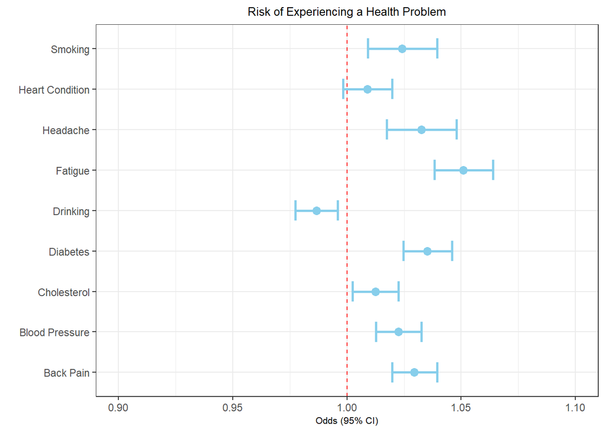

```r
log_odds_plot(health_problem_base, title = "Risk of Experiencing a Health Problem")
```

### Control Model

```r
sjPlot::tab_model(
  problem_models_control[[1]]$model, problem_models_control[[2]]$model,
  problem_models_control[[3]]$model, problem_models_control[[4]]$model,
  problem_models_control[[5]]$model, problem_models_control[[6]]$model,
  problem_models_control[[7]]$model, problem_models_control[[8]]$model,
  problem_models_control[[9]]$model,
  pred.labels = c("Intercept", "Procrastination", "Depression", "Procrastination x Depression"),
  title = "Binary Logistic Regression Analysis Predicting Likelihood of Health Problems (with Control)",
  dv.labels = health_problems,
  collapse.ci = TRUE, p.style = "stars")
```

Binary Logistic Regression Analysis Predicting Likelihood of Health Problems (with Control)

|  | Back Pain | Headache | Fatigue | Drinking | Smoking | Blood Pressure | Diabetes | Cholesterol | Heart Condition |
| --- | --- | --- | --- | --- | --- | --- | --- | --- | --- |
| Predictors | Odds Ratios | Odds Ratios | Odds Ratios | Odds Ratios | Odds Ratios | Odds Ratios | Odds Ratios | Odds Ratios | Odds Ratios |
| Intercept | 0.26 *** (0.18 – 0.38) | 0.04 *** (0.02 – 0.08) | 0.04 *** (0.02 – 0.07) | 1.90 *** (1.33 – 2.72) | 0.14 *** (0.08 – 0.27) | 0.84 (0.59 – 1.20) | 0.16 *** (0.11 – 0.24) | 0.26 *** (0.18 – 0.39) | 0.23 *** (0.15 – 0.34) |
| Procrastination | 1.02 ** (1.01 – 1.03) | 1.01 (0.99 – 1.04) | 1.03 ** (1.01 – 1.05) | 1.00 (0.98 – 1.01) | 1.02 (1.00 – 1.04) | 1.02 ** (1.01 – 1.03) | 1.03 *** (1.02 – 1.04) | 1.01 (1.00 – 1.03) | 1.01 (0.99 – 1.02) |
| Depression | 1.36 *** (1.15 – 1.60) | 1.26 * (1.01 – 1.56) | 1.48 *** (1.21 – 1.80) | 1.04 (0.89 – 1.21) | 1.16 (0.91 – 1.48) | 1.07 (0.91 – 1.26) | 0.89 (0.74 – 1.06) | 1.15 (0.98 – 1.35) | 1.13 (0.96 – 1.34) |
| Procrastination x Depression | 1.00 (0.99 – 1.00) | 1.00 (0.99 – 1.01) | 1.00 (0.99 – 1.01) | 1.00 (0.99 – 1.00) | 1.00 (0.99 – 1.01) | 1.00 (1.00 – 1.01) | 1.00 (1.00 – 1.01) | 1.00 (0.99 – 1.00) | 1.00 (0.99 – 1.00) |
| Observations | 1354 | 1356 | 1356 | 1356 | 705 | 1361 | 1361 | 1358 | 1361 |
| R<sup>2</sup> Tjur | 0.076 | 0.056 | 0.177 | 0.013 | 0.028 | 0.020 | 0.035 | 0.010 | 0.008 |
| * p<0.05 ** p<0.01 *** p<0.001 |  |  |  |  |  |  |  |  |  |

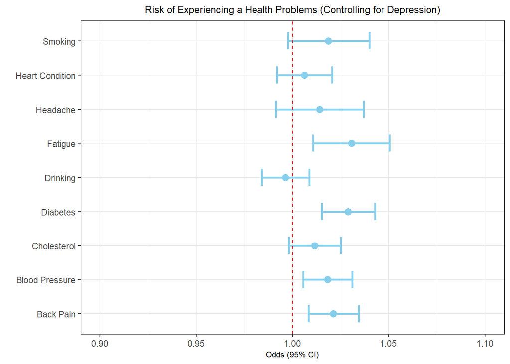

```r
log_odds_plot(health_problem_control, title = "Risk of Experiencing a Health Problems (Controlling for Depression)")
```

## Health Protection

### Base Model

```r
sjPlot::tab_model(
  protection_models_base[[1]]$model, protection_models_base[[2]]$model,
  protection_models_base[[3]]$model, protection_models_base[[4]]$model,
  protection_models_base[[5]]$model, protection_models_base[[6]]$model,
  pred.labels = c("(Intercept)", "Procrastination"),
  dv.labels = health_protection,
  title = "Binary Logistic Regression Analysis Predicting Likelihood of Health Protective Behaviours",
  collapse.ci = TRUE, p.style = "stars")
```

Binary Logistic Regression Analysis Predicting Likelihood of Health Protective Behaviours

|  | Prostate Exam | Mammogram | Cholesterol Screening | Pap Smear | Flu Shot | Dental Visit (2yrs) |
| --- | --- | --- | --- | --- | --- | --- |
| Predictors | Odds Ratios | Odds Ratios | Odds Ratios | Odds Ratios | Odds Ratios | Odds Ratios |
| (Intercept) | 2.60 *** (1.59 – 4.28) | 3.75 *** (2.56 – 5.56) | 5.90 *** (4.14 – 8.49) | 0.76 (0.53 – 1.09) | 2.65 *** (1.96 – 3.60) | 3.77 *** (2.79 – 5.12) |
| Procrastination | 0.98 * (0.97 – 1.00) | 0.98 ** (0.97 – 0.99) | 0.99 * (0.98 – 1.00) | 0.99 (0.98 – 1.00) | 0.99 (0.98 – 1.00) | 0.98 *** (0.97 – 0.99) |
| Observations | 497 | 854 | 1346 | 851 | 1356 | 1359 |
| R<sup>2</sup> Tjur | 0.008 | 0.009 | 0.004 | 0.001 | 0.001 | 0.017 |
| * p<0.05 ** p<0.01 *** p<0.001 |  |  |  |  |  |  |

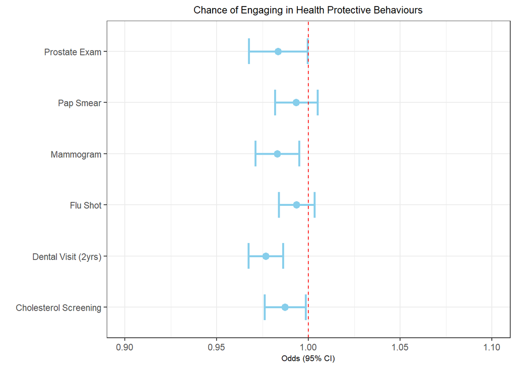

```r
log_odds_plot(health_protection_base, title = "Chance of Engaging in Health Protective Behaviours")
```

### Control Model

```r
sjPlot::tab_model(
  protection_models_control[[1]]$model, protection_models_control[[2]]$model,
  protection_models_control[[3]]$model, protection_models_control[[4]]$model,
  protection_models_control[[5]]$model, protection_models_control[[6]]$model,
  pred.labels = c("Intercept", "Procrastination", "Depression", "Procrastination x Depression"),
  title = "Binary Logistic Regression Analysis Predicting Likelihood of Health Protective Behaviours (with Control)",
  dv.labels = health_protection,
  collapse.ci = TRUE, p.style = "stars")
```

Binary Logistic Regression Analysis Predicting Likelihood of Health Protective Behaviours (with Control)

|  | Prostate Exam | Mammogram | Cholesterol Screening | Pap Smear | Flu Shot | Dental Visit (2yrs) |
| --- | --- | --- | --- | --- | --- | --- |
| Predictors | Odds Ratios | Odds Ratios | Odds Ratios | Odds Ratios | Odds Ratios | Odds Ratios |
| Intercept | 3.80 *** (2.08 – 7.10) | 4.43 *** (2.73 – 7.28) | 6.54 *** (4.20 – 10.30) | 0.86 (0.55 – 1.34) | 2.88 *** (1.99 – 4.21) | 4.67 *** (3.21 – 6.85) |
| Procrastination | 0.97 ** (0.95 – 0.99) | 0.98 * (0.96 – 1.00) | 0.99 (0.97 – 1.00) | 0.99 (0.97 – 1.00) | 0.99 (0.98 – 1.00) | 0.97 *** (0.96 – 0.98) |
| Depression | 0.77 (0.55 – 1.06) | 0.87 (0.72 – 1.05) | 0.91 (0.76 – 1.10) | 0.95 (0.79 – 1.14) | 0.94 (0.80 – 1.11) | 0.87 (0.74 – 1.02) |
| Procrastination x Depression | 1.01 * (1.00 – 1.02) | 1.00 (1.00 – 1.01) | 1.00 (1.00 – 1.01) | 1.00 (1.00 – 1.01) | 1.00 (1.00 – 1.01) | 1.00 (1.00 – 1.01) |
| Observations | 497 | 854 | 1346 | 851 | 1356 | 1359 |
| R<sup>2</sup> Tjur | 0.021 | 0.012 | 0.005 | 0.003 | 0.002 | 0.020 |
| * p<0.05 ** p<0.01 *** p<0.001 |  |  |  |  |  |  |

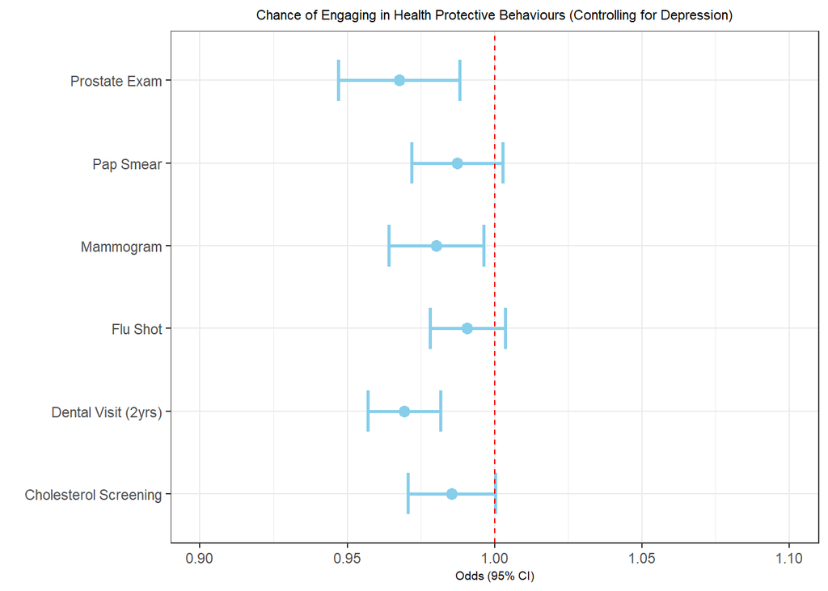

```r
log_odds_plot(health_protection_control, title = "Chance of Engaging in Health Protective Behaviours (Controlling for Depression)", size_font = 7)
```